# Heart disease prediction

## COMPARATIVE ANALYSIS FOR HEART DISEASE PREDICTION

### Objective

We aim to find the model that best predicts heart disease risk so that it can be used to screen for the disease in high-risk populations.

```python
#Libraries used in this analysis
import os
import pandas as pd
import numpy as np
import matplotlib.pyplot as plt
import datetime, warnings, scipy
import seaborn as sns
from sklearn import preprocessing
from kneed import KneeLocator
from sklearn.preprocessing import LabelEncoder
from sklearn import metrics
from sklearn.model_selection import train_test_split
from sklearn.linear_model import LogisticRegression
from sklearn.cluster import KMeans
from sklearn.neighbors import KNeighborsClassifier
from sklearn import svm
```

```python
#Setting the path for our project
os.chdir("D:\Shubh")
os.getcwd()
```

```
'D:\\Shubh'
```

```python
# Lets Load the dataset
data = pd.read_csv("heart.csv")
# lets Preview the first 5 lines of our dataset
data.head()
```

|  | age | sex | cp | trtbps | chol | fbs | restecg | thalachh | exng | oldpeak | slp | caa | thall | output |
| --- | --- | --- | --- | --- | --- | --- | --- | --- | --- | --- | --- | --- | --- | --- |
| 0 | 63 | 1 | 3 | 145 | 233 | 1 | 0 | 150 | 0 | 2.3 | 0 | 0 | 1 | 1 |
| 1 | 37 | 1 | 2 | 130 | 250 | 0 | 1 | 187 | 0 | 3.5 | 0 | 0 | 2 | 1 |
| 2 | 41 | 0 | 1 | 130 | 204 | 0 | 0 | 172 | 0 | 1.4 | 2 | 0 | 2 | 1 |
| 3 | 56 | 1 | 1 | 120 | 236 | 0 | 1 | 178 | 0 | 0.8 | 2 | 0 | 2 | 1 |
| 4 | 57 | 0 | 0 | 120 | 354 | 0 | 1 | 163 | 1 | 0.6 | 2 | 0 | 2 | 1 |

```python
# Checking the shape of the heart dataset
print("The Dimensions of the dataframe:")
#The number of columns
print("Columns:\t{}".format(data.shape[1]))
#The number of rows
print("Rows:\t\t{}".format(data.shape[0]))
```

```
The Dimensions of the dataframe:
Columns:	14
Rows:		303
```

The results shows that our dataset has 14 columns and 303 rows.

```python
#Analyzing the presence of missing values
data.isnull().sum()
```

```
age         0
sex         0
cp          0
trtbps      0
chol        0
fbs         0
restecg     0
thalachh    0
exng        0
oldpeak     0
slp         0
caa         0
thall       0
output      0
dtype: int64
```

The results above shows that there are no missing values.

```python
#Characteristic of the variables
data.info()
```

```
<class 'pandas.core.frame.DataFrame'>
RangeIndex: 303 entries, 0 to 302
Data columns (total 14 columns):
 #   Column    Non-Null Count  Dtype
---  ------    --------------  -----
 0   age       303 non-null    int64
 1   sex       303 non-null    int64
 2   cp        303 non-null    int64
 3   trtbps    303 non-null    int64
 4   chol      303 non-null    int64
 5   fbs       303 non-null    int64
 6   restecg   303 non-null    int64
 7   thalachh  303 non-null    int64
 8   exng      303 non-null    int64
 9   oldpeak   303 non-null    float64
 10  slp       303 non-null    int64
 11  caa       303 non-null    int64
 12  thall     303 non-null    int64
 13  output    303 non-null    int64
dtypes: float64(1), int64(13)
memory usage: 33.3 KB
```

The results show that most variables are integers

```python
#Separating numerical variables from categorical variables
NumericV = ["age", "trtbps", "chol", "thalachh", "oldpeak"]
CategoricalV = ["sex", "cp", "fbs", "restecg", "exng", "slp", "caa", "thall", "output"]
```

### Eploratory data analysis

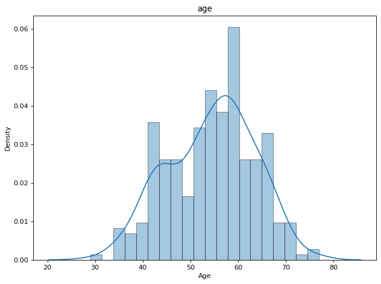

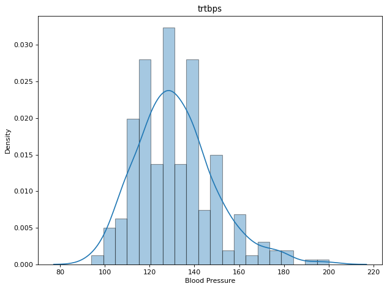

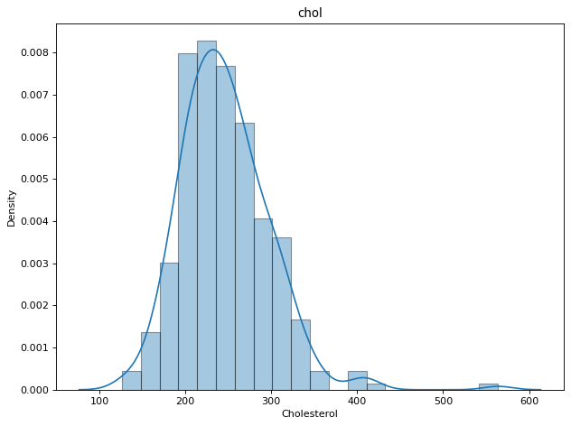

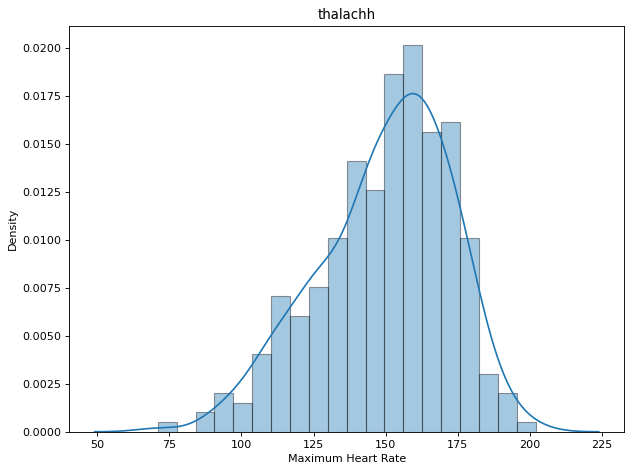

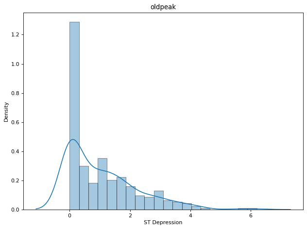

```python
#Naming the axis
NumericV_axis_name = ["Age", "Blood Pressure", "Cholesterol", "Maximum Heart Rate", "ST Depression"]

for i, z in list(zip(NumericV, NumericV_axis_name)):
    plt.figure(figsize = (8, 6), dpi = 80)
    sns.distplot(data[i], hist_kws = dict(linewidth = 1, edgecolor = "k"), bins = 20)

    plt.title(i)
    plt.xlabel(z)
    plt.ylabel("Density")

    plt.tight_layout()
    plt.show()
```

The following can be observed from the results above;

- Most patients are between the age of 50 and 60 years.
- Most patients has a resting blood pressure between 110 and 140.
- Most patients has a cholesterol value of between 200 and 280.
- Most patients achieved a maximum heart rate between 145 and 170.

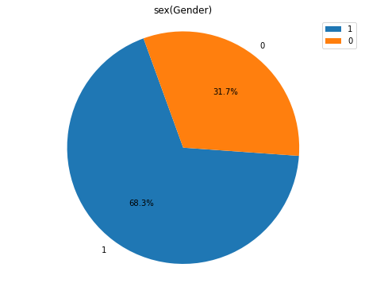

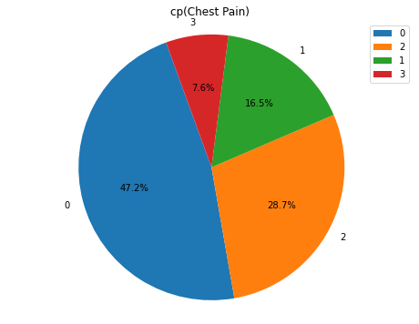

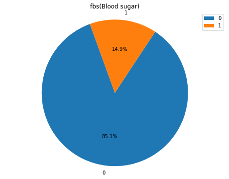

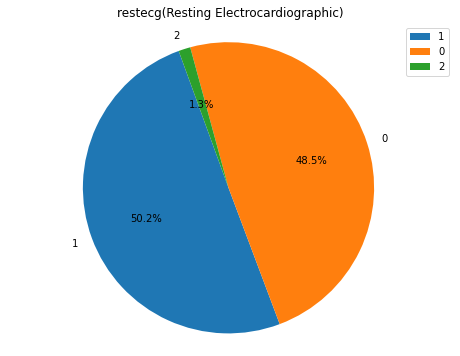

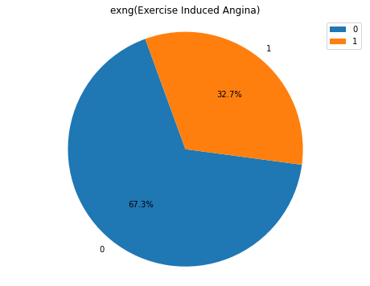

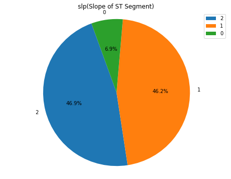

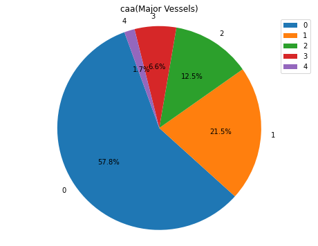

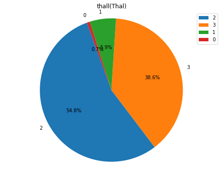

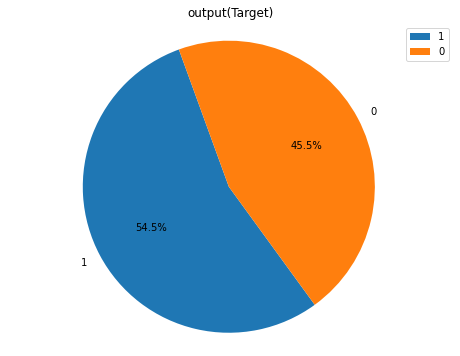

```python
#Naming the axis
CategoricalV_axis_name = ["Gender", "Chest Pain", "Blood sugar", "Resting Electrocardiographic",
                      "Exercise Induced Angina", "Slope of ST Segment", "Major Vessels", "Thal", "Target"]

#Pie charts for categorical variables
for i, z in list(zip(CategoricalV, CategoricalV_axis_name)):
    fig, ax = plt.subplots(figsize = (8, 6))

    observed_value = list(data[i].value_counts().index)
    Total_value = list(data[i].value_counts())

    ax.pie(Total_value, labels= observed_value, autopct = '%1.1f%%', startangle = 110, labeldistance = 1.1)
    ax.axis("equal")

    plt.title((i + "(" + z + ")"))
    plt.legend()
    plt.show()
```

The results shows that

- 68.3% of the patients are male and 31.7% are female.
- 54.5% have a heart attack risk and the remaining 45.5% have no heart attack risk.

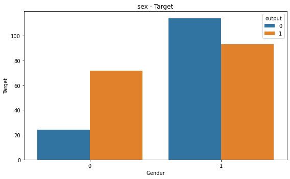

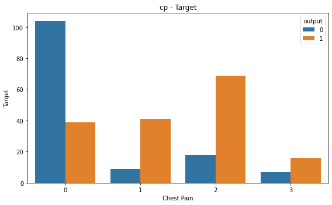

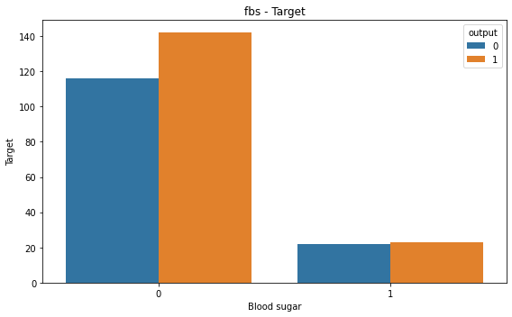

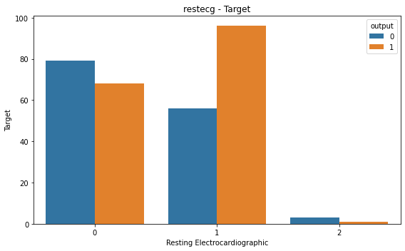

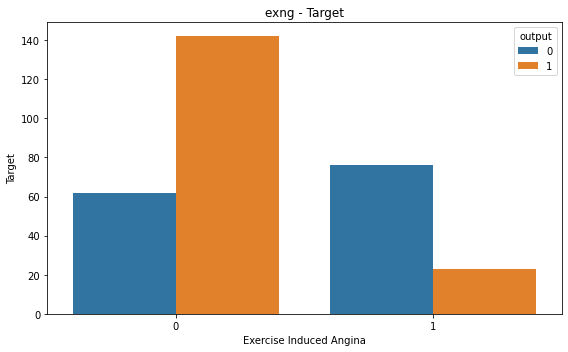

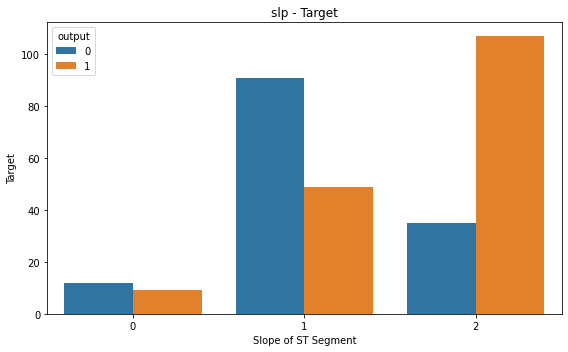

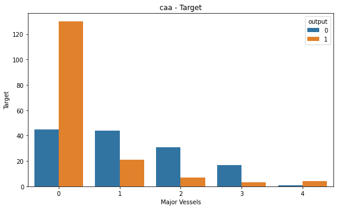

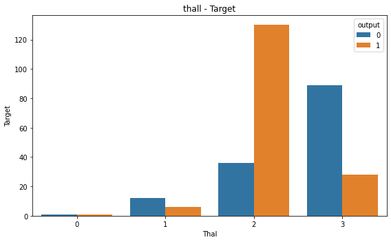

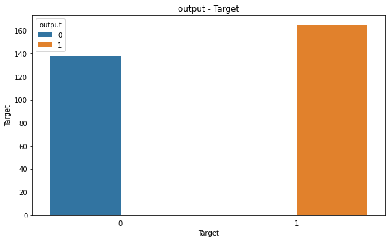

```python
for i, z in list(zip(CategoricalV, CategoricalV_axis_name)):
    plt.figure(figsize = (8, 5))
    sns.countplot(i, data = data[CategoricalV], hue = "output")

    plt.title(i + " - Target")
    plt.xlabel(z)
    plt.ylabel("Target")

    plt.tight_layout()
    plt.show()
```

From the results above, we note the following;

- Females are at a higher risk to have heart attack than males
- The 0 group under CAA is primarily at risk
- Patients with a value of thal 2 are three times more likely to have a heart attack than if they have not.

#### Correlation

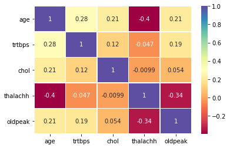

```python
Numerical1 = data[["age", "trtbps", "chol", "thalachh", "oldpeak"]]
# Heatmap
sns.heatmap(Numerical1.corr(), cmap="Spectral", annot = True, linewidths = 0.5)
```

- Age has the highest negative correlation with "thalach"

### MODELLING

```python
#Data
new_data = data

#Converting some variables to categorical variables
new_data['sex'] = new_data['sex'].astype('category')
new_data['cp'] = new_data['cp'].astype('category')
new_data['fbs'] = new_data['fbs'].astype('category')
new_data['restecg'] = new_data['restecg'].astype('category')
new_data['exng'] = new_data['exng'].astype('category')
new_data['slp'] = new_data['slp'].astype('category')
new_data['caa'] = new_data['caa'].astype('category')
new_data['thall'] = new_data['thall'].astype('category')
new_data['output'] = new_data['output'].astype('category')
```

#### Splitting the dataset into training and test data

```python
#defining 'X' and 'Y'
Y = new_data['output']
X = new_data.drop('output', axis = 1 , inplace = False)

#Scaling The Data
X = preprocessing.StandardScaler().fit(X).transform(X.astype(float))

#splitting the data
x_train, x_test, y_train, y_test = train_test_split(X, Y, test_size = 0.3, random_state = 4)
```

#### CLASSIFICATION

```python
#Calculating the number of k using codes
shubh = []
for i in range(1,10):
  kmeans = KMeans(n_clusters = i, init = 'k-means++', max_iter = 1001, n_init = 9, random_state = 4)
  kmeans.fit(x_train)
  shubh.append(kmeans.inertia_)

knee_loc = KneeLocator(range(1, 10),shubh, curve="convex", direction="decreasing")
knee_loc.elbow
```

```
4
```

```python
#Create KNN Classifier
Knn_model = KNeighborsClassifier(n_neighbors=4)

#Train the model
Knn_model.fit(x_train, y_train)

#Predict the response
Y_PredKnn_model = Knn_model.predict(x_test)

#Evaluation
print("The Accuracy of the knn model is:",metrics.accuracy_score(y_test, Y_PredKnn_model))
```

```
The Accuracy of the knn model is: 0.7142857142857143
```

#### 2. Logistic regression

```python
logistic_model = LogisticRegression()
# fitting the model
logistic_model.fit(x_train,y_train)

#prediction
y_pred=logistic_model.predict(x_test)

#Evaluation
print("The Accuracy of the logistic regression model is:",metrics.accuracy_score(y_test, y_pred))
```

```
The Accuracy of the logistic regression model is: 0.8021978021978022
```

#### 3. Support Vector Machine

```python
svm_model = svm.SVC(kernel='linear') # Linear Kernel
#Train the model
svm_model.fit(x_train, y_train)

#Prediction
y_predictSVM = svm_model.predict(x_test)

print("The Accuracy of the support vector machine model is:",metrics.accuracy_score(y_test, y_predictSVM))
```

```
The Accuracy of the support vector machine model is: 0.7912087912087912
```

- Therefore the best performing was Logistic regression model, which had an accuracy score of 0.8021978021978022.